# OSMtidy - Vignette 3, Filters

Dr Annie Visser-Quinn, a.visser-quinn@hw.ac.uk

2020-08-11

## 1. Introduction

OSMtidy aims to tidy up physical object data extracted from OpenStreetMaps. Steps 1-4 cover the extraction of this data and wrangling into a suitable format. Step 5, data filtering, is central to OSMtidy. Through filters, a multi-column database of physical objects can be converted into a simple two-column geotagged database - describing the name and geometry/ location of the object.

There are approximately 1250 predefined filters in OSMtidy. These can be explored and modified via the spreadsheet filters.xlsx in the OSMtidy directory. The filters are provided in spreadsheet form for ease of use - OSMtidy is primarily intended to be used by non-specialists and non-coders. The following figures provide a brief overview of the spreadsheet layout and navigation.

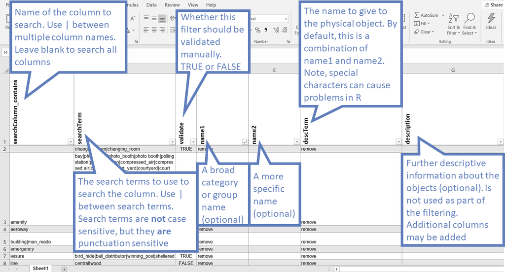

1.1 *filters.xlsx* overview and column descriptions.

[figure not shown]

1.2. Navigating *filters.xlsx*.

## 2. Creating your first filter

This vignette uses a subset of data from the Edinburgh ward examplar (see Vignettes 1 and 2). The input file is located within the *vignettes* folder.

```r
dlWrangle <- readRDS("vignettes/files/vignette3Input_dataWrangle.RDS")

dlWrangle$dataWrangled
```

```
#> [[1]]
#> Simple feature collection with 380 features and 15 fields
#> geometry type:  GEOMETRY
#> dimension:      XY
#> bbox:           xmin: -3.199224 ymin: 55.95748 xmax: -3.163603 ymax: 55.97478
#> geographic CRS: WGS 84
#> First 10 features:
#>       osm_id barrier fence_type feature                     name
#> 1   22415647    <NA>       <NA> leisure      London Road Gardens
#> 2   31455917    <NA>       <NA> leisure           St Mark's Park
#> 3   23165357    <NA>       <NA> leisure              Pilrig Park
#> 4   32781795    <NA>       <NA> leisure              Keddie Park
#> 5   39960556    <NA>       <NA> leisure            Redbraes Park
#> 6   73014417    <NA>       <NA> leisure      Dalmeny Street Park
#> 7  100007410    <NA>       <NA> leisure      Broughton Road Park
```

[output cut: 36 more lines]

There are 380 objects in this dataset. In the output above, a header of the dataset is printed. A number of parks are listed, so let’s start by creating a filter for parks.

- Open *filterTemplate.xlsx* and save it as *filters (1).xlsx* in the example folder.
- To search all columns, leave *searchColumn_contains blank*
- Use *park* as the *searchTerm*
- Set *validate* to *TRUE*
- Fill in *name1*, *name2* and *descTerm* - this example uses names consistent with *filters.xlsx*
- Save the spreadsheet

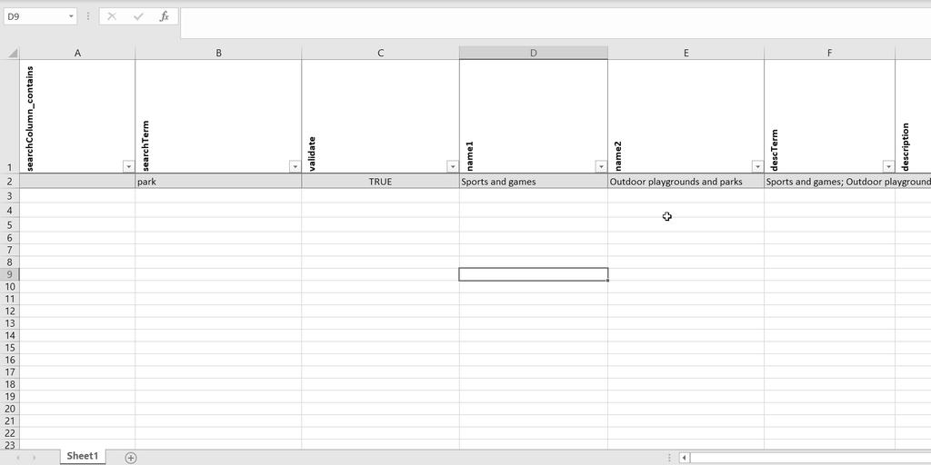

2.1. First filter, set up to find parks.

Now that the first filter is ready, you can run it in R. Because we set validate to TRUE, we want to export the output to explore the validate spreadsheet.

```r
dlFilter <- dlWrangle %>% dataFilter("vignettes/files/vignette3Input_filters1.xlsx")
```

```
#> 15:52:31 Step one of one
#> 15:52:32 Complete, preparing output
```

```r
dlFilter %>% dataExport(., "filterExample_round1")
```

```
#> Files saved as:
#>
#>  outputs/filterExample_round1_5_dataFilter-unfiltered_20200811-155232.xlsx
#>  outputs/filterExample_round1_5_dataFilter-filtered_20200811-155232.csv
#>  outputs/filterExample_round1_5_dataFilter-filtered_20200811-155232.RDS
#>  outputs/filterExample_round1_5_dataFilter-validate_20200811-155232.xlsx
```

The *filterExample_round1_5_dataFilter-validate* spreadsheet can be found in the *outputs* folder. It should look something like the figure below.

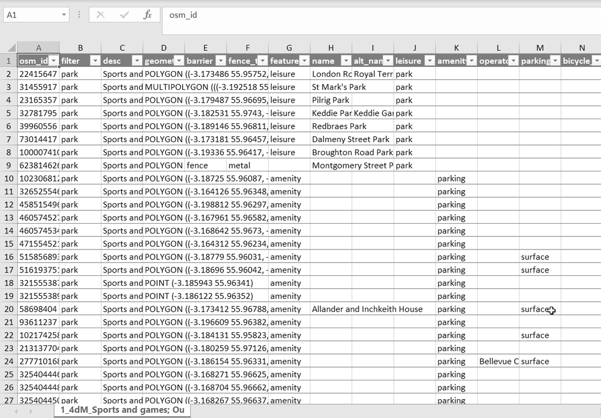

2.2. Validate spreadsheet for the first filter.

Entries 2-9 show that the filter did capture the parks. Parking has also been picked up because the filter was *not specific enough*. Section 3 explores the iterative process to fix this.

## 3. Adjusting filters - An iterative process

Open *filters (1).xlsx* and add a more specific filter for parking (see figure below). Add this filter before the park filter. OSMtidy is iterative and applies filters in the same order as they are in the spreadsheet. Save this new filter as *filters (2).xlsx* and run the R code again.

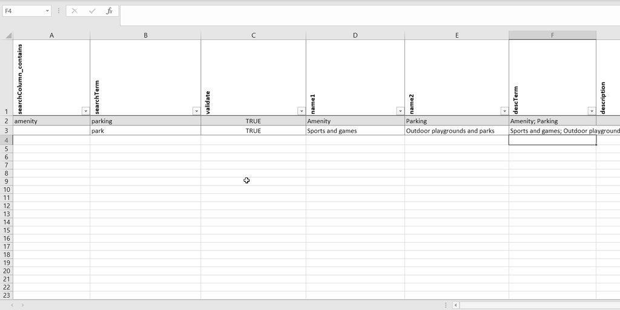

3.1. Adding a second more specific filter.

```r
dlFilter <- dlWrangle %>% dataFilter("vignettes/files/vignette3Input_filters2.xlsx")
```

```
#> 15:52:32 Step one of one
#> 15:52:32 Complete, preparing output
```

```r
dlFilter %>% dataExport(., "filterExample_round2")
```

```
#> Files saved as:
#>
#>  outputs/filterExample_round2_5_dataFilter-unfiltered_20200811-155232.xlsx
#>  outputs/filterExample_round2_5_dataFilter-filtered_20200811-155233.csv
#>  outputs/filterExample_round2_5_dataFilter-filtered_20200811-155233.RDS
#>  outputs/filterExample_round2_5_dataFilter-validate_20200811-155233.xlsx
```

The new *validate* spreadsheet has two tabs. Clicking on the drop-down arrow shows that the *parking* filter picked up three different objects.

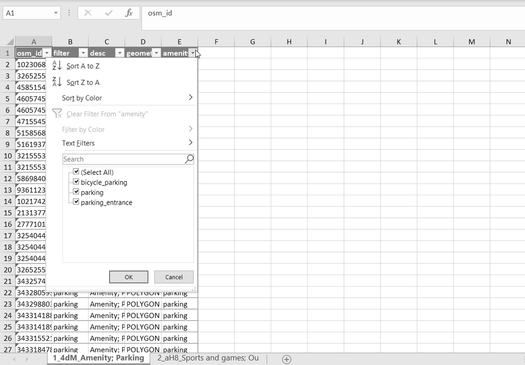

3.2. *Validate* spreadsheet after adding a second filter.

Update the filters spreadsheet again, and rerun the R code.

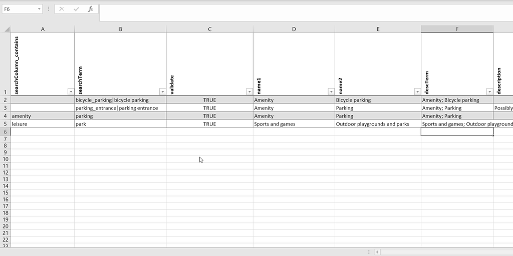

3.3. Third iteration of the *filters* spreadsheet. Two new filters are added.

```r
dlFilter <- dlWrangle %>% dataFilter("vignettes/files/vignette3Input_filters3.xlsx")
```

```
#> 15:52:33 Step one of one
#> 15:52:33 Complete, preparing output
```

```r
dlFilter %>% dataExport(., "filterExample_round3")
```

```
#> Files saved as:
#>
#>  outputs/filterExample_round3_5_dataFilter-unfiltered_20200811-155233.xlsx
#>  outputs/filterExample_round3_5_dataFilter-filtered_20200811-155233.csv
#>  outputs/filterExample_round3_5_dataFilter-filtered_20200811-155233.RDS
#>  outputs/filterExample_round3_5_dataFilter-validate_20200811-155233.xlsx
```

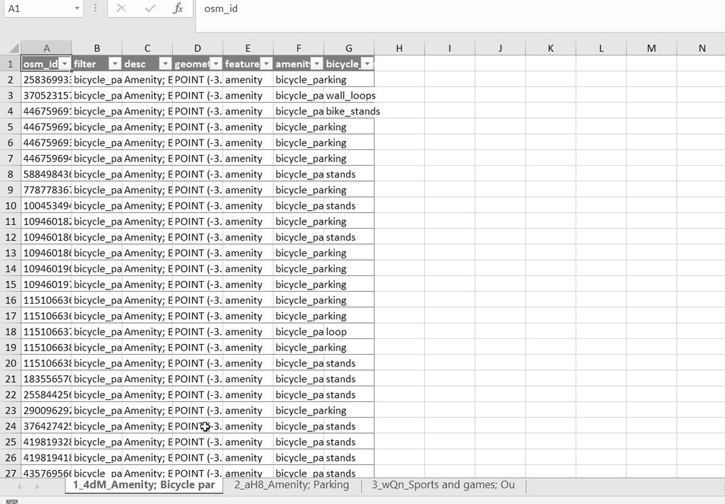

3.4. *Validate* spreadsheet after the third iteration. There are now three tabs. Use the drop-down menu to determine if the filter identified unique objects.

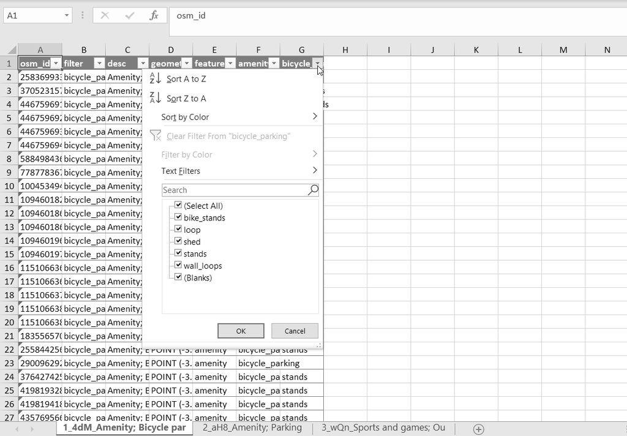

3.4. The bicycle_parking column reveals additional information that could be filtered for.

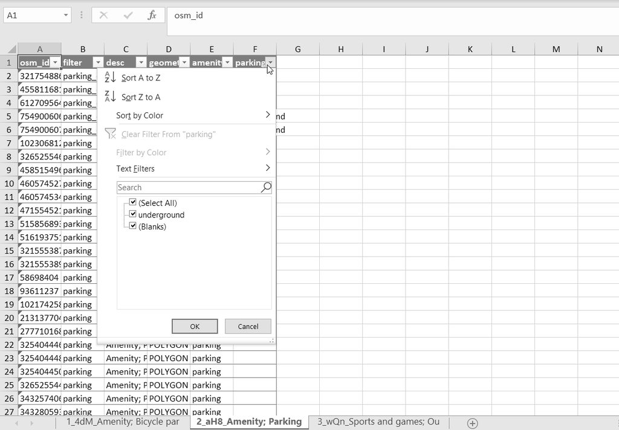

3.5. In the second tab, the parking column reveals additional information that could be filtered for.

These outputs show that the filters have improved, but they aren’t quite specific enough. More detailed bicycle parking filters might be useful, and filters for underground parking are needed. This requires a fourth iteration of filters.

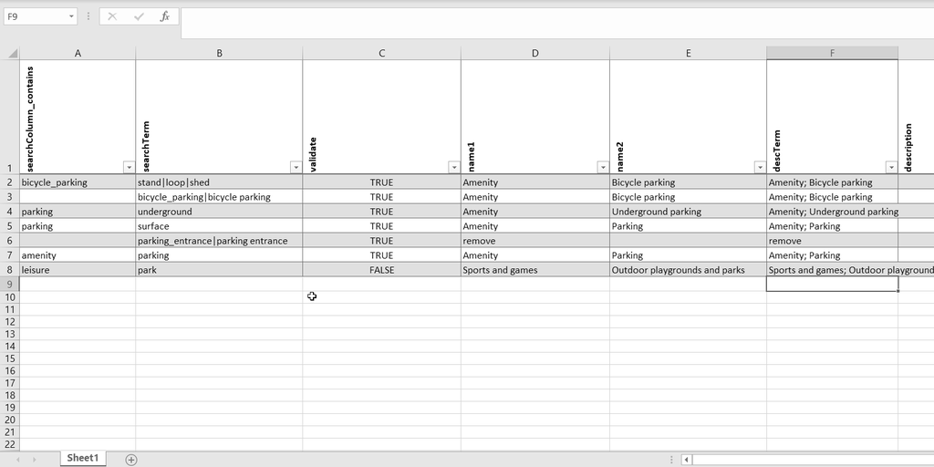

3.6. Fourth iteration of the *filters* spreadsheet. Three new filters are added and *validate* is changed for *park*.

```r
dlFilter <- dlWrangle %>% dataFilter("vignettes/files/vignette3Input_filters4.xlsx")
```

```
#> 15:52:33 Step one of one
#> Warning: `select_()` is deprecated as of dplyr 0.7.0.
#> Please use `select()` instead.
#> 15:52:34 Complete, preparing output
```

```r
dlFilter %>% dataExport(., "filterExample_round4")
```

```
#> Files saved as:
#>
#>  outputs/filterExample_round4_5_dataFilter-unfiltered_20200811-155234.xlsx
#>  outputs/filterExample_round4_5_dataFilter-filtered_20200811-155234.csv
#>  outputs/filterExample_round4_5_dataFilter-filtered_20200811-155234.RDS
#>  outputs/filterExample_round4_5_dataFilter-validate_20200811-155234.xlsx
```

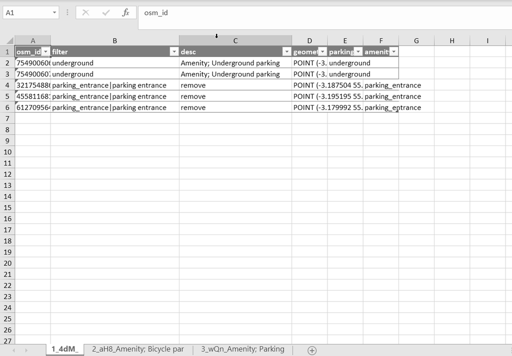

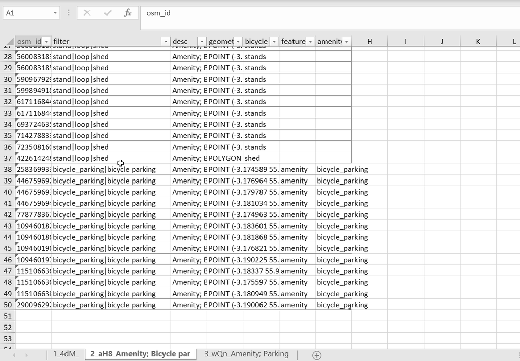

3.8. Tab 2. With the new bicycle parking filter the object descriptions agree with the filters.

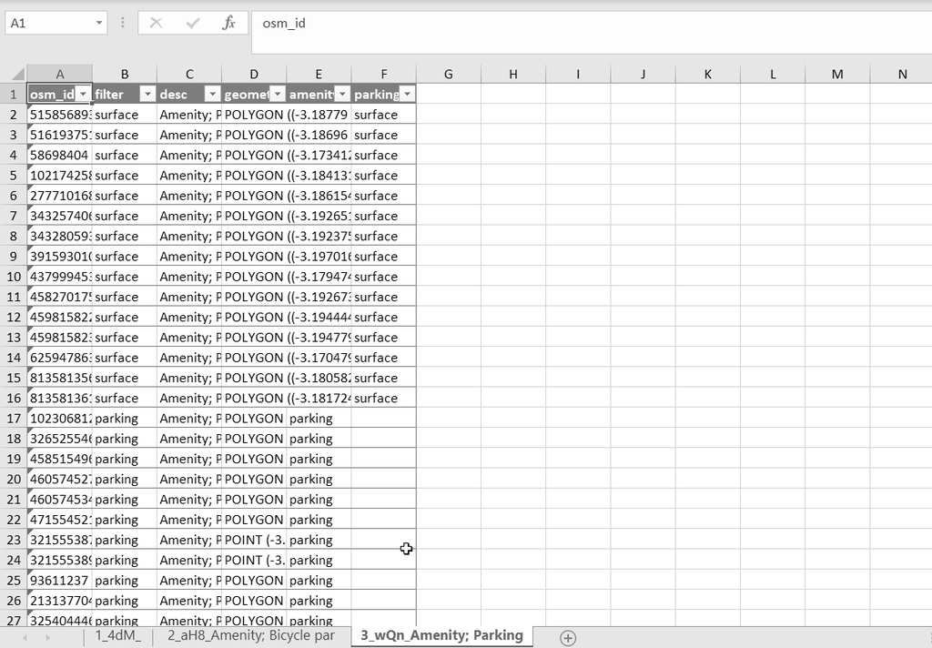

3.9. Tab 3. The same is true for parking.

Through these four iterations, the *park* filter was refined to become specific enough to capture the range of similar objects.

## 4. Identifying new filters

Whether starting a filter spreadsheet from scratch, or using the pre-determined filters in *filters.xlsx*, some objects will be missed. To identify new filters, open the *unfiltered* spreadsheet in the *outputs* folder.

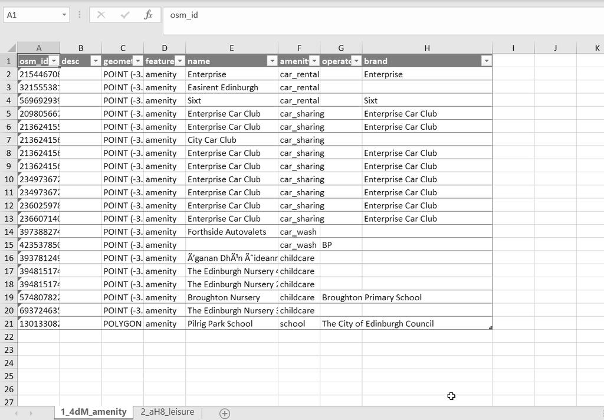

4.1. Two tabs of unfiltered objects.

These objects can be manually updated, by changing the *desc* column (see Vignette 4), or by identifying new filters. In the figure below, a number of new filters are added in an attempt to capture some of these objects. The filters which have been validation (in section 3) are changed to *validate FALSE*.

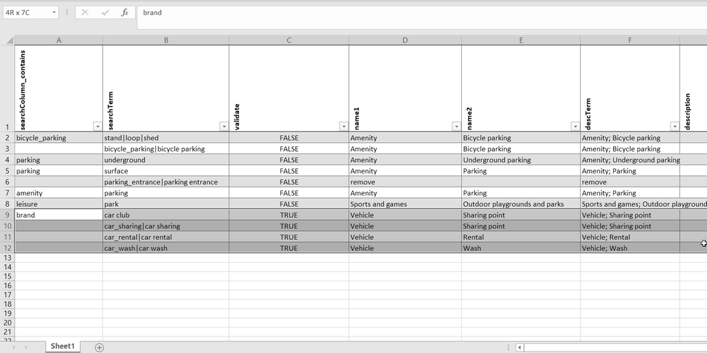

4.2. Fifth iteration of the *filters* spreadsheet. Four new filters are added and *validate* is updated.

```r
dlFilter <- dlWrangle %>% dataFilter("vignettes/files/vignette3Input_filters5.xlsx")
```

```
#> 15:52:34 Step one of one
#> 15:52:34 Complete, preparing output
```

```r
dlFilter %>% dataExport(., "filterExample_round5")
```

```
#> Files saved as:
#>
#>  outputs/filterExample_round5_5_dataFilter-unfiltered_20200811-155234.xlsx
#>  outputs/filterExample_round5_5_dataFilter-filtered_20200811-155234.csv
#>  outputs/filterExample_round5_5_dataFilter-filtered_20200811-155234.RDS
#>  outputs/filterExample_round5_5_dataFilter-validate_20200811-155234.xlsx
```

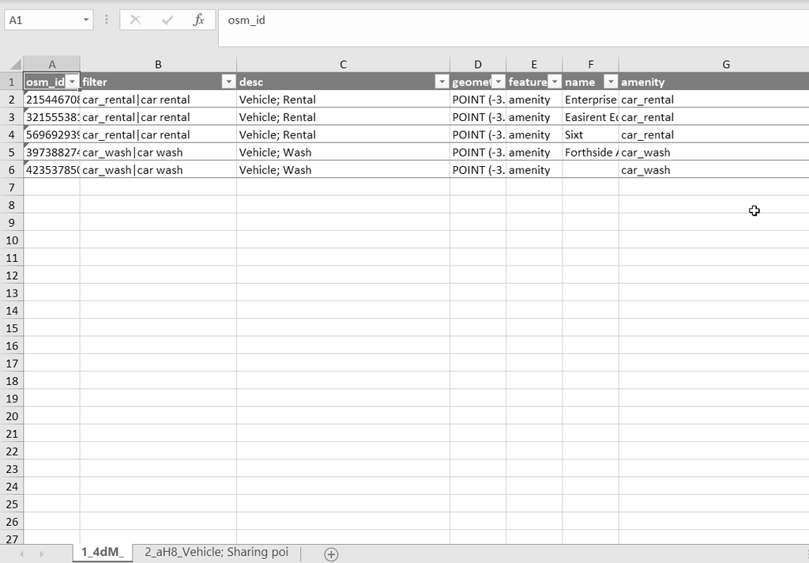

4.3. *Validate* spreadsheet after the fifth iteration. Filters in the first tab appear successful.

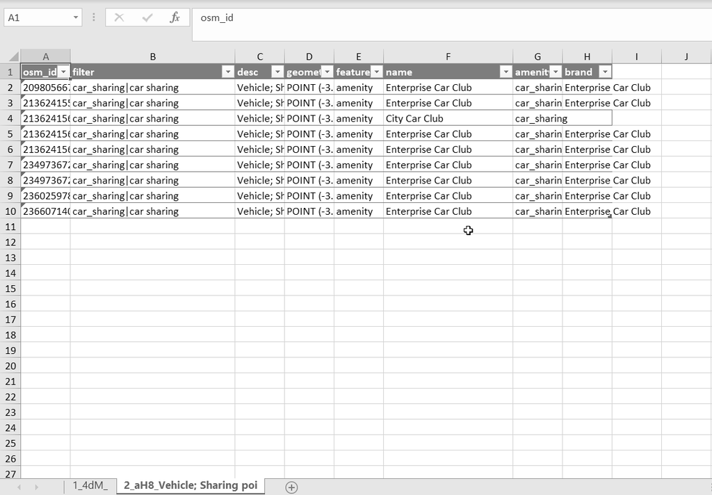

4.4. Filters in the second tab also appear valid.

[figure not shown]

```r
dlFilter <- dlWrangle %>% dataFilter("vignettes/files/vignette3Input_filters6.xlsx")
```

```
#> 15:52:34 Step one of one
#> 15:52:35 Complete, preparing output
```

```r
dlFilter %>% dataExport(., "filterExample_round6")
```

```
#> Files saved as:
#>
#>  outputs/filterExample_round6_5_dataFilter-unfiltered_20200811-155235.xlsx
#>  outputs/filterExample_round6_5_dataFilter-filtered_20200811-155235.csv
#>  outputs/filterExample_round6_5_dataFilter-filtered_20200811-155235.RDS
#>  outputs/filterExample_round6_5_dataFilter-validate_20200811-155235.xlsx
```

## 5. Manually updating the *validate* spreadsheet

In some instances, it may not be possible to identify a specific enough filter. In these instances, you could specify the osm_id as a filter, or, you can manually edit the validate output.

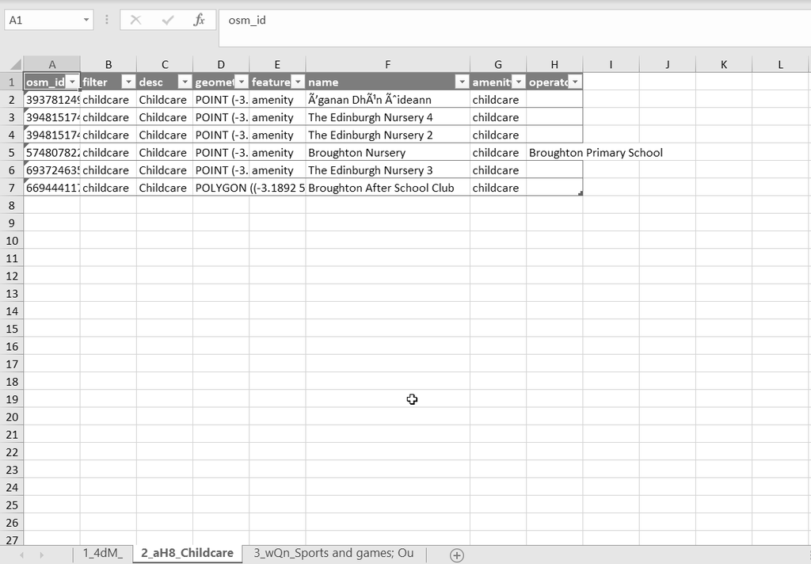

5.1. *Validate* spreadsheet after the final iteration. The descriptor childcare does not necessarily reflect the object information.

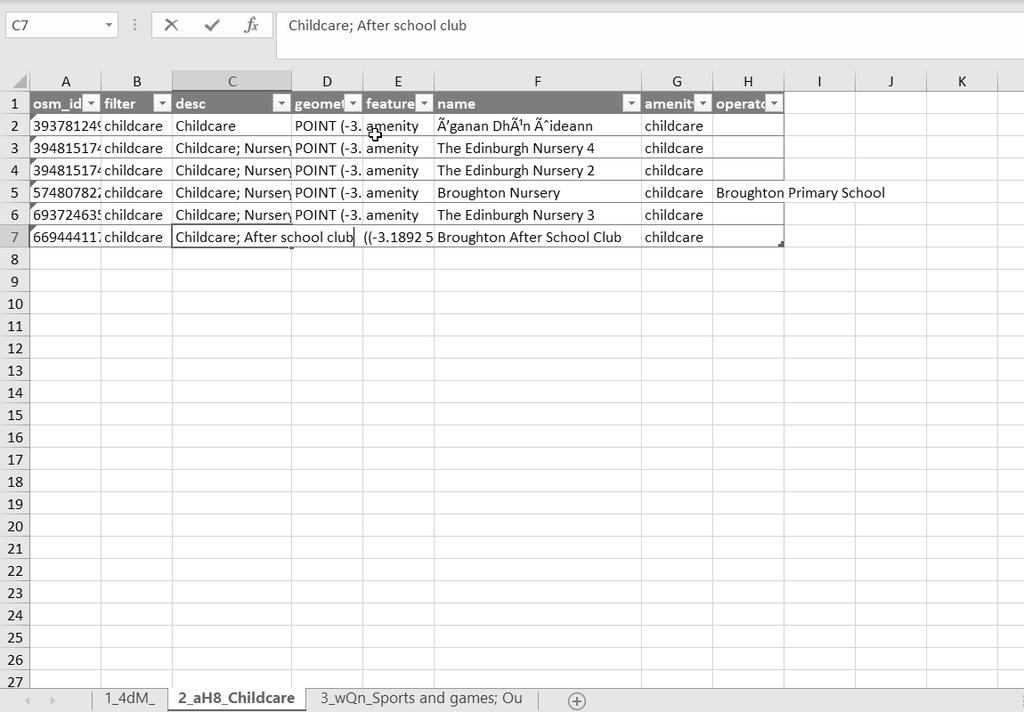

5.2. The *validate* spreadsheet *desc* column is updated to reflect the additional information available.

The validate spreadsheet can be editted for a number of reasons:

- You want to remove the object, change the entry in *desc* to *remove*
- It was a *Keyword filter* - a filter which looks for a keyword and needs to be manually adjusted. If *Keyword filter* is not removed from *desc*, it won’t be included in the final OSMtidy output
- To avoid rerunning filters - e.g. for a city location that takes multiple hours to run filters

These changes can be imported as part of the final step in OSMtidy, using the function `dataTidy()`.

```r
inputList <- list(dlFilter$filtered,
                  "outputs/filterExample_round6_5_dataFilter-validate_20200710-130213.xlsx")
```

```r
dlTidy <- dataTidy(inputList)
dlTidy %>% dataSummary
```

```
#> $class
#> [1] "list"             "OSMtidy_dataTidy"
#>
#> $summary
#> # A tibble: 2 x 3
#>   data     total percent
#>   <chr>    <int>   <dbl>
#> 1 remove       3     0.8
#> 2 filtered   374    99.2
#>
#> $summaryFiltered
#> # A tibble: 9 x 2
#>   desc                                            total
#>   <chr>                                           <int>
#> 1 Amenity; Bicycle parking                           49
#> 2 Amenity; Parking                                  282
#> 3 Amenity; Underground parking                        2
#> 4 Childcare                                           6
#> 5 School                                              1
#> 6 Sports and games; Outdoor playgrounds and parks    20
#> 7 Vehicle; Rental                                     3
#> 8 Vehicle; Sharing point                              9
#> 9 Vehicle; Wash                                       2
```

The output can be saved using `dataExport()`. The fourth vignette explores how to edit other spreadsheet outputs from OSMtidy.